# Do Live Texts Reduce Early Bus Departures?

Office of Performance Management

2024-08-07

## Study Objective

The purpose of this analysis is to examine whether contacting bus operators who are running ahead of their schedule is an effective way of reducing early bus departures.

The MTA is working hard to improve on-time departure rates for bus service. Busses may leave a stop late for many reasons, but early departures are mostly at the discretion of the bus operator. Early departures are undesirable; busses that depart early may leave before boarding passengers who time their arrival based on published schedules. This may lead to frustration on the part of these passengers, and passengers may arrive at their destination late because the next scheduled bus is several minutes later than the bus they intended to take.

In order to prevent early departures, the MTA enacted an intervention in real-time. Operators receive a text message on their on-board Mobile Data Terminal when their bus is ahead of schedule. The hypothesis is that bus drivers who receive this text will be reminded to delay their bus and re-align with their scheduled route, while drivers who do not receive the text will run increasingly ahead of schedule. The null is that texting has no impact on drivers’ schedule adherence, either because drivers do not respond to the text message and continue to run early, or because all drivers naturally adjust their schedule adherence during their work pieces. Both hypotheses have supporting anecdotal evidence.

## Results Summary

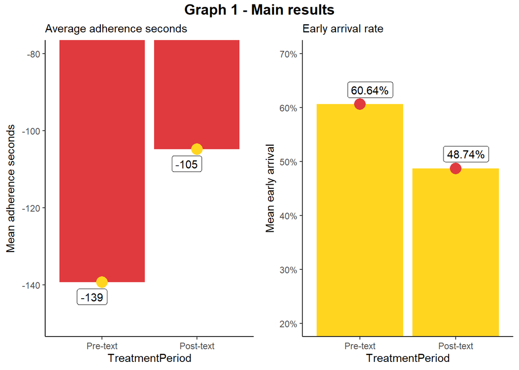

## Recommendation

Tens of thousands of work pieces ran ahead of schedule and did not receive a text message. Here is a large opportunity to expand the number of text messages sent. If it is cost-prohibitive to send a large number of text messages, we recommend identifying the subset of trips where early departures have the most negative impact on our riders, and prioritizing those to receive texts. The smallest incremental policy change is simply to send more texts to the right operators at the right times. MTA should repeat this analysis at some convenient time in the future to see whether the qualitative outcomes change.

## Methodology

In order to complete this analysis, I used the Adherence data in the OPM Data Warehouse to identify work pieces. A work piece is a single, continuous sequence of stops within a TripId and OperatorId on a given day. For example, if an operator works a given Trip on Monday, and then again on Tuesday, they have completed two separate work pieces. If an operator runs one trip and then another in one day, that is their work, with one Trip being a work piece.

I classified work pieces based on a) whether the operator ran ahead of their schedule on that work piece and b) whether the operator received a text during their work piece. For work pieces in the second group, I associated the text message with a specific stop on the work piece Texts are matched to stops where they received the text message prior to departing that stop, but after departing the previous stop in the same run. As I discuss below, it is not necessarily the case that all operators who received texts were running ahead of their schedule when they received the text.

I classified work pieces in the first group that did not receive a text (a but not b) as “Comparison” work pieces. A work piece was classified as a comparison work piece if it had 40 or more stops, the average early departure rate was greater than 40%, and the average adherence seconds was less than -40. These comparison work pieces allow us to see whether operators self-correct early runs without the aid of a text message. It may have been the case that the text message arrives at about the same time that bus operators would self-correct anyway. Without a comparison group, we may have erroneously attributed the effect of operators’ own self-corrections to the arrival of the text message.

The table below reports basic counts of text, operators, and runs by group.

Table 1 - Summary statistics of study

| Statistic | Value |
| --- | --- |
| Total text messages sent | 786 |
| Operators targeted for texts | 403 |
| Texts successfully matched to specific stop/trip/operator | 455 |
| Operators in the treatment group | 308 |
| Operators in the comparison group | 1101 |
| Runs in the treatment group | 455 |
| Runs in the comparison group | 28648 |

### Time Point Stops

This analysis incorporates time point stops. In estimating the average effect of texts on drivers’ behavior, I use all stops because this relates directly to rider experience. Riders are unaware of which stops are time point stops and which are not, and so the overall efficacy of the text intervention should be calculated at the stop level rather than the time-point stop level.

In estimating individual drivers’ reactions to the text messages, I use only time-point stops. I did this because the analysis of individual drivers’ behavior may be used later in employment actions. It is important, then, to condition the analysis on time-point stops.

### Aggregating across individual operators’ data

In order to answer the question, we must average across individual operators and runs. To understand how I did this, consider a single work piece by an operator who received a text. In the panel below, Graph 2.1 shows that operator’s adherence time for each stop plotted against the time the bus departed from the stop. Graph 2.2 shows the same data, but the X-axis has been adjusted to be the stop sequence relative to the stop at which the operator received the text message. Organizing the data in this second way allows us to aggregate and analyze all messages and operators by “relative stop,” the stop sequence relative to the stop at which the operator received their message.

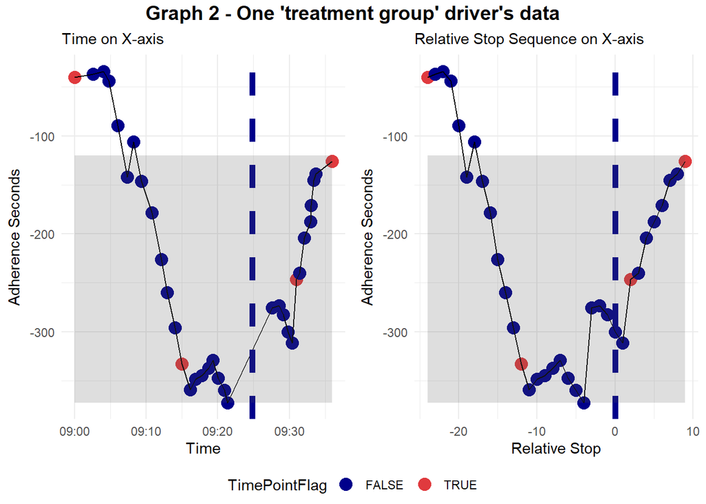

#### Comparison Group

The comparison group ran ahead of their schedules but did not receive a text. In order to be able to compare the comparison and treatment groups, I sequenced stops relative to the median stop in each run. Graph 3 below shows one operator’s run before and after the stop re-sequencing.

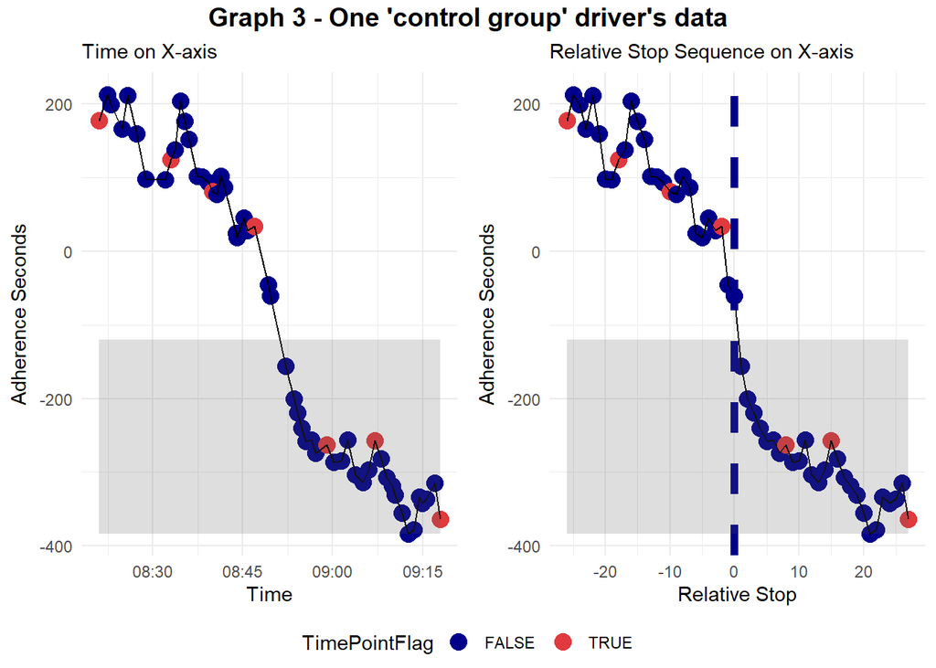

## Detailed Results

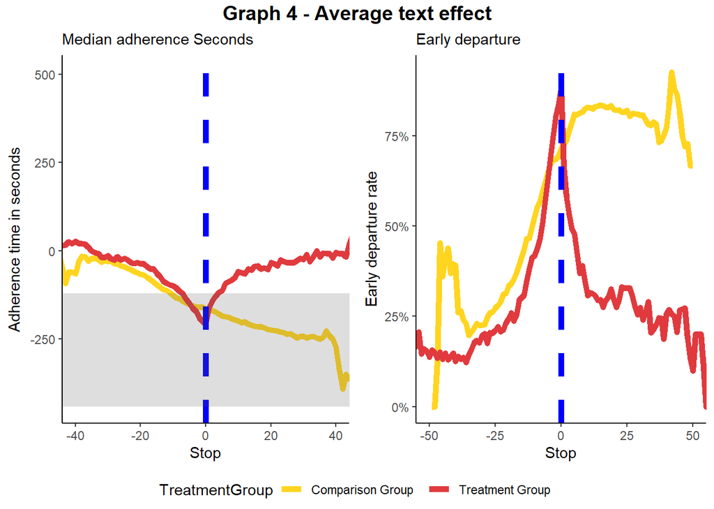

### Average Text Effect

Since our comparison group is not a true control group, I chose to use a Regression Discontinuity Design (RDD) without a second-order difference to estimate the impact of texts on drivers’ behavior. A difference-in-difference analysis in this case would likely over-state the impact of the text messages, as the comparison group is not a true control.

$$y_s = \beta_0 + \beta_1(S_s) +
\beta_2(T_s) + \beta_3(T_s)(S_s) + \mu_s$$

Outcomes for stop s - adherence seconds and early departures - ($y_s$) are a function of stop sequence (S) and treatment period (T). The coefficient ($\beta_3$) on the interaction term will show the level effect of the text on each outcome. Again, remember that this data includes **all stops, not just time-point stops**. The table below reports the results of the regression. Model (1) shows that adherence seconds increased on average by 34 seconds after the text message was received, and then 8 seconds with each subsequent stop. Model (2) shows that early departure rates decreased on average by 12% after the text was received, and then -2% with each subsequent stop. Both regressions show an immediate and lasting impact of text messages, on average.

**Table 2 - Regression Results**

|  | *Dependent variable:* |  |
| --- | --- | --- |
|  | Adherence Seconds | Early |
|  | (1) | (2) |
| Average Change per stop | -3.881*** (-4.050, -3.711) | 0.012*** (0.012, 0.013) |
| Average post-treatment outcome | 34.560*** (27.692, 41.428) | -0.119*** (-0.136, -0.102) |
| Average per stop change in the outcome post-treatment | 7.942*** (7.619, 8.265) | -0.020*** (-0.021, -0.019) |
| Average Outcome | -139.373*** (-143.607, -135.140) | 0.606*** (0.596, 0.617) |
| Observations | 22,608 | 22,608 |
| *Note:* | p<0.1; p<0.05; p<0.01 |  |

### Empirically estimating individual text efects

I also estimated each individual operators’ text effect. Again, this regression **only uses time-point stops**. My form is:

$$y_s = \beta_0 + \beta_1(S_s) +
\gamma(T_s)(R_s) + \delta(T_s)(S_s)(W_s) + \mu_s$$

Outcomes at each stop - adherence seconds and early departures - ($y_s$) are a function of stop sequence (S), treatment period (T), and WorkPiecId (W). The elements of ($\hat{\gamma}$) indicate the degree to which text messages immediately impact a driver’s behavior, and the elements of ($\hat{\delta}$) show the improvement over time after receiving the text for each driver. The elements of ($\hat{\gamma}$) are graphed below with 95% confidence intervals.

Graph 5.1 plots the elements of ($\hat{\gamma}$) and shows that most operators - those with point estimates above 0 - seem to have increased their average adherence seconds in response to receiving a text. Confidence intervals on these point estimates are tight, and most Operators’ estimates are statistically different from zero.

Graph 5.2 shows that most operators managed to reduce their average early departure rate after receiving the text. Though fewer point estimates here are statistically different from zero, most of them are below zero.

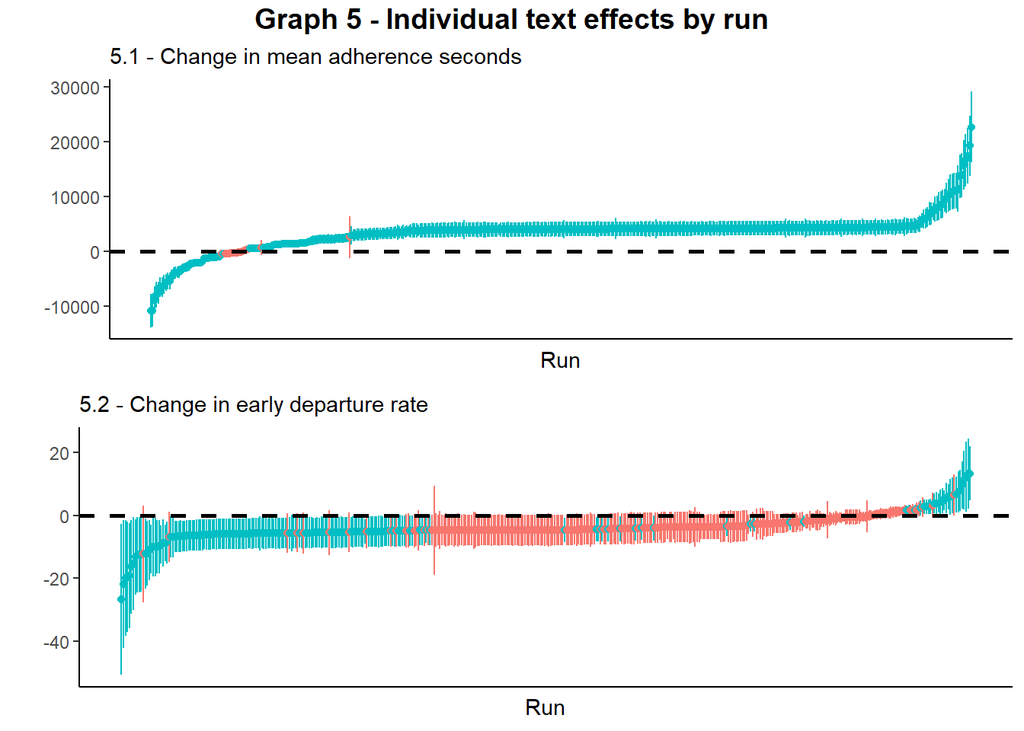

### Idiosyncratic treatment effects

In Graph 5.1, runs with a positive estimated effects can be classified as ‘Compliers’ in that they complied with the text’s instruction to slow down. By the same logic, runs with a negative or zero estimated effect can be classified as ‘Noncomplier.’ Table 3 below shows the count of work pieces by classification. Table 4 shows the count of Operators by work piece classification. Note that the unit of observation is a work piece, not an operator. An operator that received multiple text during different work pieces may be counted as both a complier and a noncomplier, depending on their response to each text.

Table 3 - Run count by effect sign

| Outcome Group | Work Pieces |
| --- | --- |
| Complier | 382 |
| Noncomplier | 48 |

Table 4 - Operator count by effect sign

| Outcome Group | Operators |
| --- | --- |
| Complier | 264 |
| Noncomplier | 46 |

#### Non-complier examples

Graph 6 below shows two examples of ‘noncompliers’ - operators who seem to not react to the text message they receive.

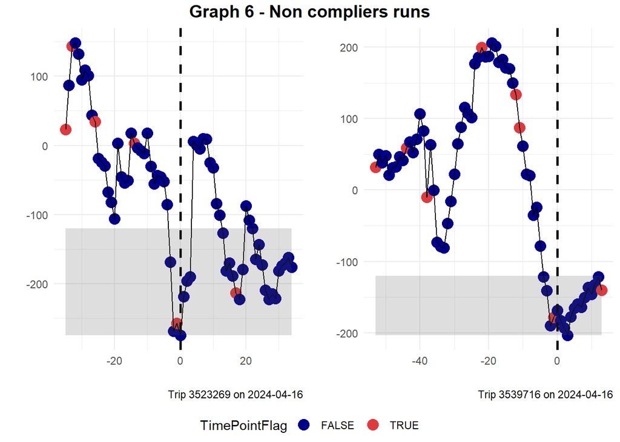

#### Complier examples

Graph 7 shows two examples of operators who reacted to the text message.

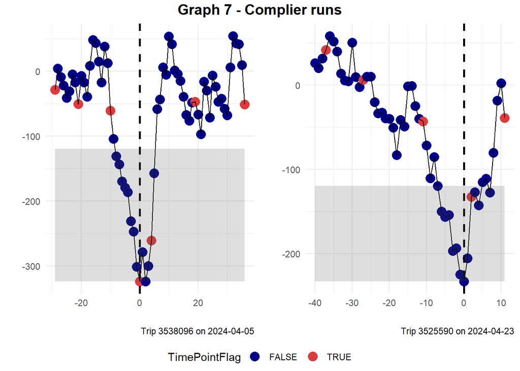

## Reliability of message data

There are a number of issues with the message data that frustrated this analysis. We found four main issues with the message data:

- The adherence table had no records for the Date and OperatorId associated with certain messages.
- There are duplicated rows in the adherence table - different rows have the same TripId, OperatorId, and DepartureDateTime. However, the stop names are different. This causes a failure to match a text to a specific stop, since the matchin requires stops to be sequential in time.
- Messages arrived between two runs or after the last departure time of a run.
- Messages arrived before the first departure time of a run.

#### Duplicated rows

There are two duplicate rows in the messages data: OperatorIds (7274 , 90568) received two messages at the same time (2024-04-17 15:04:46, 2024-04-22 10:42:33).

#### Messages to drivers who aren’t running early

Visually inspecting individual runs, I found some where the operator received a text despite running on schedule.

## Attribution

This analysis was conducted by Anqi Li (OPM), Ana Daley (OPM), and Rob Ross . Work is stored on [GitHub](https://github.com/MTA-MD-OPM/ds_early_bus_departure_intervention_study/tree/main).